# Plotting Data 2

Joanna Lawler

# 4.8 Activiy: Fix the Plots

In this worksheet, we’ll be looking at some erroneous plots and fixing them. I think you might not have these two packages installed:

```r
# install.packages("ggridges")
# install.packages("scales")
```

The exercsies below include some data wrangling function. It’s okay if you aren’t familiar with them all yet! We will get into a lot of them over the next few weeks, but see if you can figure out what they are doing as you go.

```r
library(tidyverse)
library(gapminder)
library(ggridges)
library(scales)
```

# Exercise 1: Overlapping Points

Fix the overlapping data points problem in the following plot by adding an `alpha` or `size` argument (attribution: [“R for data science”](https://r4ds.had.co.nz/data-visualisation.html)).

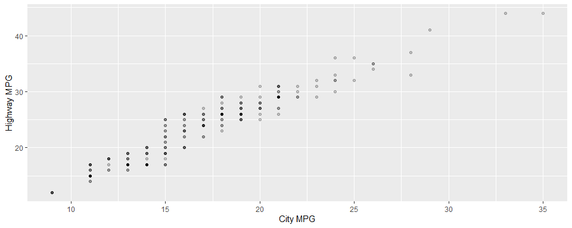

```r
mpg %>%
  ggplot(aes(cty, hwy)) +
  geom_point(alpha = 0.2) +
  xlab("City MPG") +
  ylab("Highway MPG")
```

# Exercise 2: Line for Each Country

Fix this plot so that it shows life expectancy over time with a separate line *for each country*.

Notice that we tried to use `group_by()`. We will cover that next week. But also notice that `ggplot2` ignores the grouping of a tibble!

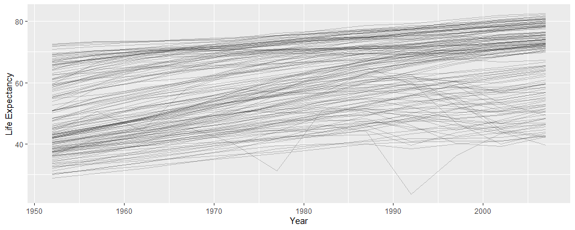

```r
gapminder %>%
  ggplot(aes(year, lifeExp)) +
  geom_line(aes(group = country), alpha = 0.2) +
  xlab("Year") +
  ylab("Life Expectancy")
```

# Exercise 3: More gdpPercap vs. lifeExp

## 3(a) Facets

- Change the x-axis text to be in “comma format” with `scales::comma_format()`.
- Separate each continent into sub-panels.

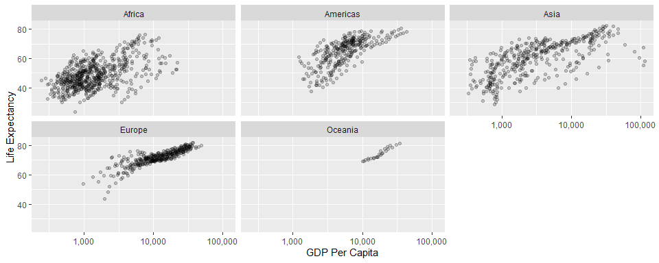

```r
gapminder %>%
  ggplot(aes(gdpPercap, lifeExp)) +
  geom_point(alpha = 0.2) +
  scale_x_log10("GDP Per Capita", labels = scales::comma_format()) +
  facet_wrap(vars(continent)) +
  ylab("Life Expectancy")
```

## 3(b) Bubble Plot

- Put the plots in one row, and free up the axes (let them have different scales).
- Make a bubble plot by making the size of the points proportional to population.
  - Try adding a `scale_size_area()` layer too (could also try `scale_radius()` but that is not optimal for perception).
- Use `shape=21` to distinguish between `fill` (interior) and `color` (exterior).

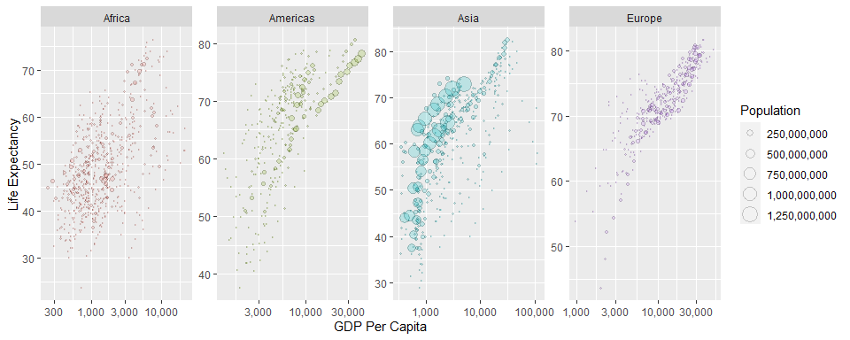

```r
gapminder %>%
  filter(continent != "Oceania") %>%
  ggplot(aes(gdpPercap, lifeExp, size = pop, fill = continent, options(scipen = 999))) +
  facet_wrap(vars(continent), nrow = 1, scales = "free") +
  geom_point(alpha = 0.2, shape = 21) +
  scale_x_log10("GDP Per Capita", labels = scales::comma_format()) +
  scale_size_area("Population", labels = scales::comma_format()) +
  ylab("Life Expectancy") +
  guides(fill = FALSE)
```

A list of shapes can be found [at the bottom of the `scale_shape` documentation](https://ggplot2.tidyverse.org/reference/scale_shape.html).

## 3(c) Size “Not Working”

Instead of alpha transparency, suppose you’re wanting to fix the overplotting issue by plotting small points. Why is this not working? Fix it.

It was not working because a parenthesis needed to follow the specification of the x and y variables.

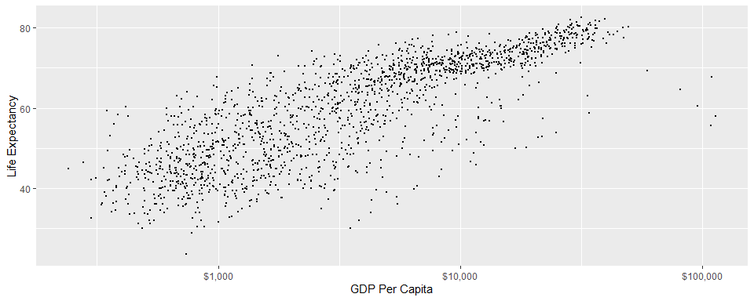

```r
gapminder %>%
  ggplot() +
  geom_point(aes(gdpPercap, lifeExp), size = 0.1) +
  scale_x_log10("GDP Per Capita", labels = scales::dollar_format()) +
  ylab("Life Expectancy")
```